# Pollination service delivery is complex: Urban garden crop yields are best explained by local canopy cover and garden scale plant species richness - McDougall - - Journal of Applied Ecology - Wiley On

[figure not shown]

[figure not shown]

RESEARCH ARTICLE

Open Access

# Pollination service delivery is complex: Urban garden crop yields are best explained by local canopy cover and garden scale plant species richness

[Robert McDougall](https://besjournals.onlinelibrary.wiley.com/action/doSearch?ContribAuthorRaw=McDougall%2C+Robert),

[Paul Kristiansen](https://besjournals.onlinelibrary.wiley.com/action/doSearch?ContribAuthorRaw=Kristiansen%2C+Paul),

[Tanya Latty](https://besjournals.onlinelibrary.wiley.com/action/doSearch?ContribAuthorRaw=Latty%2C+Tanya),

[Jeremy Jones](https://besjournals.onlinelibrary.wiley.com/action/doSearch?ContribAuthorRaw=Jones%2C+Jeremy),

[Romina Rader](https://besjournals.onlinelibrary.wiley.com/action/doSearch?ContribAuthorRaw=Rader%2C+Romina),

First published: 14 February 2022

https://doi.org/10.1111/1365-2664.14136

**Handling Editor:** Fabrice Requier

## 1 INTRODUCTION

Urban environments present both opportunities and challenges for insect pollinators. They can contain a high diversity of plants and floral resources generally beneficial to pollinating insects (Clarke & Jenerette, 2015), but at the same time also have high levels of impervious surfaces and otherwise disturbed landscapes (McKinney, 2008), limiting availability of other resources, such as nesting habitat. As around 75% of global food crops benefit from insect pollinators (Klein et al., 2007), and a diversity of food crops are grown in urban gardens (McDougall et al., 2019), understanding the factors that influence insect pollinators and their resource needs in urban environments is critical as the global demand for food production increases.

While a number of studies have investigated how environmental factors impact insect pollinators in urban food gardens, the results of these have been varied. For example, floral resources are often positively associated with pollinator abundance or diversity in community gardens (e.g. Davis et al., 2017; Lin et al., 2015; Matteson & Langellotto, 2010; Quistberg et al., 2016; Tasker et al., 2019), a finding that reflects the situation commonly seen in rural systems (Klein et al., 2007). However, not all studies have found this trend (e.g. Makinson et al., 2016; Matteson & Langellotto, 2011; Plascencia & Philpott, 2017).

Urban environments also often have environmental features rarely seen in rural areas, such as soil contamination, atmospheric pollutants and altered climatic conditions (Wortman & Lovell, 2013) that can impact on food production. For example, temperature variations as a result of urban heat island effects may have significant impacts on the phenology of urban plants (Jochner & Menzel, 2015) and the timing of reproduction of social insects (Chick et al., 2019).

Despite many studies having a stated aim of investigating pollination in urban gardens, only a small number have directly assessed pollination services in these environments (e.g. Bennett & Gratton, 2012; Lowenstein et al., 2015; Potter & LeBuhn, 2015). The majority instead base their conclusions on proxy measures such as abundance, diversity or activity of pollinating organisms. Such conclusions can potentially be misleading as plant reproductive success does not necessarily follow pollinator activity (Leong et al., 2014; Tamburini et al., 2019). With urban agriculture growing in popularity across the developed world (Mok et al., 2013) more information on environmental variables and pollination within urban gardens is needed to understand whether crops can reach their full potential in these systems (Birkin & Goulson, 2015).

This study seeks to expand on previous research into ecosystem services in urban agriculture by assessing the factors influencing pollination at the scale of a single species and the sum of the impact of a broad range of ecosystem services at a system scale. At the species scale, we examine delivery of pollination services to model plants. At the system scale, we examine yields in urban gardens and how these are impacted by features of the surrounding environments. Using urban food gardens in warm temperate South-Eastern Australia, we assessed the following questions:

1. To what extent is pollination of a model plant affected by features of the urban environment (e.g. density of development, floral resources)?
2. How do these environmental features impact the output of crops in urban agriculture through the delivery of ecosystem services more generally?

## 2 MATERIALS AND METHODS

We established model plants within gardens, observed pollinator visitation to these and recorded their reproductive output. We recorded data on crop yield within gardens and compared each of these to a range of environmental variables.

### 2.1 Study sites

Experiments were carried out during summer of 2016 in 15 food producing gardens, including private and community gardens, in the cities of Sydney and Wollongong, New South Wales, Australia (see Appendix S1 in Supporting Information).

### 2.2 Observation of floral visitors

#### 2.2.1 Model plants

Pollinator visitation was measured by observing potted *Brassica rapa* subsp. *chinensis* (pak choi) plants (S2). The cultivar of *B. rapa* selected as a model is known to respond strongly to insect pollination (Rader et al., 2009; Walker et al., 2009). Model plants were deployed after flower buds began to develop but before these opened, ensuring their only pollinator exposure occurred at study sites. Due to variations in development times between individuals, plants were deployed in a staggered fashion, with batches transported to each site once sufficient replicates had reached this stage. Plants were deployed from 5 to 25 October and placed together at each site in a cluster of 12–14 plants.

#### 2.2.2 Pollinator observations

We recorded all insects that contacted a flower on a model plant during a number of 20-min observation periods at each site. Insects were assigned to morphospecies in the field and photographed using a Canon EOS1200D camera with Tamron SP 60 mm F/2 Macro lens. After each observation period, unidentified flower visitors were captured during a further 10-min period to allow for identification by taxonomists, linking morphospecies observed on the wing with more reliable laboratory identifications. Bees and hoverflies were identified to genus or species and other organisms to family. It was not possible to capture specimens of all organisms observed so in some cases we relied on photographs for identification.

Observations were carried out at each site every 4–6 days for as long as open flowers were present on model plants. This resulted in each site being visited five to nine times, with variation resulting from weather and different flowering periods. Where necessary, the differing number of observations between sites was accounted for in statistical analyses, as outlined below. Observations were carried out on mostly sunny days between 10 am and 4 pm (time of day each site was visited varied between observations), with no observations conducted if it was overcast, raining, or if wind speed was >5 m/s.

### 2.3 Measurement of reproductive success

Individual plants were returned from the field once all flowers on that plant had closed on or before 11 December. Returned plants were kept in a greenhouse while seeds matured. Once seed pods were mature but prior to them dehiscing (when they became brittle to the touch) the ratio of flowers producing seed pods to those not producing any was counted, pods were removed and the average seed weight for each plant and number of seeds per pod were recorded.

Weight of seeds was measured using a Sartorius Analytic Balance and the number of seeds per plant was counted via weighing, with four samples of 100 seeds from each plant weighed to determine the average weight per seed, and the total weight of seeds produced by that plant being divided by this value.

While deployed at study sites, many of the plants suffered damage to their inflorescences, likely due to the effects of weather, animals and people. As a result, around 25% of inflorescences were missing their upper parts, with the majority of plants across all sites having some damaged inflorescences. To avoid this potentially confounding results, complete and incomplete inflorescences from each plant were recorded separately until statistical tests could determine if there were significant differences between the two conditions.

Wilcoxon tests were used to check for differences in reproductive output across the two conditions and these revealed no significant difference in individual seed weight (*p* = 0.113) or seeds per pod (*p* = 0.910). However, a significant difference was found in the proportion of flowers producing pods between the two conditions (*p* < 0.001). Therefore, complete and incomplete inflorescences were combined for analyses of seed weight and seeds per pod, however, pod production was measured only in complete inflorescences.

### 2.4 Hand pollination

At each site, two to three model plants were hand pollinated to ascertain if reproductive output was pollen limited (Ouvrard et al., 2017). Each of these plants were pollinated on every site visit by brushing stamens from experimental greenhouse plants on the stigmas of open flowers of the hand pollinated plants. Pollinator exclusion has been shown to reduce seed set in the strain of *B. rapa* used by over 50% Walker et al. (2009) so it was anticipated that hand pollinated plants would show increased reproductive output if model plants were pollen limited.

We assessed differences in reproductive output between hand pollinated and naturally pollinated plants through two methods. We used Wilcoxon tests to look for differences in raw reproductive output between treatments and also calculated the log response ratio between treatments (Hedges et al., 1999), comparing these values to 0 using two-sided *t*-tests.

### 2.5 Food crop yield

Yields of food crops from study sites were determined using logbooks maintained by gardeners working within those sites over the course of a year. Recording took place between November 2015 and May 2017. These data were used to determine productivity of sample plots within the gardens in kg of produce per m<sup>2</sup> of land cultivated and per hour of labour invested. Thirteen complete datasets were collected across 11 of the 15 study sites (McDougall et al., 2019). All research involving human subjects was approved by the University of New England Human Research Ethics Committee (approval no. HE15-196).

### 2.6 Measurement of environmental variables

Environmental variables were measured at either garden scale (within a single study garden) or landscape scale (in a 1,000 m radius around each garden).

### 2.7 Garden scale variables

Variables relating to garden vegetation and structure (Table 1) were measured through onsite observations using a number 3 m × 3 m quadrats, the combined area of which equalled 10% of the garden’s area (to a maximum of 50 quadrats). The centre point of each quadrat was selected using a random number generator.

TABLE 1. Garden scale variables

| Variable | Units |
| --- | --- |
| Floral density | Number of flowers per m<sup>2</sup> |
| Floral area | cm<sup>2</sup> of floral display per m<sup>2</sup> |
| Total plant species richness | Number at garden scale and plot scale |
| Flowering plant species richness | Number at garden scale and plot scale |
| Vegetation complexity | Unitless Structural Complexity Index |
| Garden land use diversity | Shannon’s *H* |
| Light | μmol/s/m<sup>2</sup> |
| The presence of *Tetragonula carbonaria* hive | Present/absent |
| Garden size | m<sup>2</sup> |

All quadrat measurements were carried out three times, once in summer 2016–2017 during or shortly after experimental plants were in the field and two additional times 4 and 8 months prior to experimental plant deployment during spring and autumn respectively. These earlier measurements were included as changes in resources available at one time of year can impact the insect fauna present at other times of year (Isaacs et al., 2009). Variables measured across multiple time periods were included in statistical models based on both their summer values and the mean annual values.

Floral density (number of flowers per m<sup>2</sup>) was determined by counting the number of flowers per quadrat (compound flowers were considered a single ‘floral unit’; Lowenstein et al., 2015). Number of flowers per quadrat was averaged across each site.

Floral area was defined as the total area of floral display (cm<sup>2</sup>/m<sup>2</sup>). Five flowers of each flowering species present were chosen through ad hoc selection and measured as per Hegland and Totland (2005) to determine the average flower size for each species. Total floral area per quadrat was determined by multiplying the number of flowers of each species by the average area of a flower of that species and this figure was averaged across each site.

The total number of plant species, as well as the subset of species in flower at the time of each measurement, was counted in each quadrat. We determined plant species richness and flowering species richness at each site at two scales; garden scale and quadrat scale. Garden scale species richness was determined by dividing the total number of species found across all quadrats at a site by the total number of quadrats measured at that site. For sites where more than 10 quadrats were measured species accumulation curves were plotted for both total number of species and number of flowering species to determine if all species present had been found. If curves reached asymptote, we divided the number of species by the number of quadrats required to reach asymptote. If curves did not reach asymptote, or if a site contained fewer than 10 quadrats, we divided species number by total number of quadrats. Quadrat scale richness was the mean of the number of species per quadrat across a site, regardless of whether a particular species was present in multiple quadrats.

Vegetation complexity was measured using a structural complexity index (Shrewsbury & Raupp, 2000). Each of the 1 m<sup>2</sup> squares making up a quadrat was assigned a complexity rating from 0 to 5, based on the number of vegetative strata layers it contained (ground cover/turf, herbaceous plants, shrubs, understorey trees and overstorey trees). Each quadrat was thus given a complexity rating between 0 and 45, with the average across all quadrats being a garden’s mean complexity.

Sunlight exposure was measured using a Li-Cor photometer (Model LI-189) at 30 randomly selected locations within the garden at a height of 1.5 m at noon on a cloudless summer day.

The presence of beehives was noted, with seven gardens containing hives of the Native Stingless Bee *Tetragonula carbonaria* while honeybee hives were not present in any gardens.

Land use diversity was calculated across the entirety of each garden using Shannon’s diversity index. We measured the total size of each garden and the proportions of the site that were covered by different land uses (e.g. cropping beds, lawns, impervious surfaces etc.) (Matteson & Langellotto, 2010).

### 2.8 Landscape scale variables

Landscape scale variables (Table 2) were measured in a 1 km radius around each garden and formed a gradient of moderate to heavy levels of urbanisation. Canopy cover, building density and road length were included in models based on their values for a 1,000 m radius, as well as 500 and 100 m radii around the study site.

TABLE 2. Landscape scale variables

| Variable | Range of values at 1,000 m (mean) |
| --- | --- |
| % Canopy Cover (100, 500 and 1,000 m radius) | 12.8–60.8 (36.8) |
| % Buildings (100, 500 and 1,000 m radius) | 4.2–46.7 (25.3) |
| Length of roads (m) (100, 500 and 1,000 m radius) | 7,200–72,700 (31,900) |
| Distance to bushland (m) (nearest site >1 ha in area) | 53–3,644 (788) |
| Human population density of locality (people/ha) | 0.3–91.1 (34.9) |

The proportion of the landscape within a 1 km radius of each garden covered by tree canopy (>2 m tall) and by building footprints was determined using LIDAR derived point cloud (0.5 m resolution) data (NSW Government Spatial Service, 2013) buffered to form polygons using Arc GIS 10.4.1. Total length of roads within the area was determined using a Road Centreline dataset (NSW Government Spatial Service, 2018) and summed using Arc GIS. Distance to the nearest patch of bushland at least 1 Ha in area was measured using Arc GIS. Human population density in the statistical block in which each site was located was obtained from the Australian Bureau of Statistics (2018).

### 2.9 Temperature variables

To account for the impact of temperature on pollinator visitation and plant reproduction we initially tested the response of each dependant variable to temperature in a model that contained only that fixed explanatory variable and relevant random variables (as outlined below). Temperature data were obtained from Bureau of Meteorology (2020). In the case of visitation variables we used records of temperature from the closest weather station to the garden (greatest distance 11.2 km) on the day of each observation, testing the impact of both daily maximum and mean temperature. Mean temperature had a significant impact on overall visitation and was thus included in all visitation models.

In the case of plant reproduction variables, we summed the daily mean temperature (°C above 0°C) for each site across the period that model plants were present and modelled this against all measures of reproductive output. This was not found to significantly impact any plant reproduction variables so was not included in further models.

### 2.10 Statistical analysis

We used linear mixed modelling and AICc (Burnham & Anderson, 2002) to gain an understanding of how environmental variables impacted pollinators, plant reproductive output and crop yield. As we were interested in the possible impact of many variables, we used a two-step process to select variables for analysis in order to avoid using an overly large global model that risked overfitting. In the first step, dependent variables were modelled against a single fixed explanatory variable (Tables 1 and 2) and all relevant random variables and covariates (outlined below) using linear mixed models or generalised linear mixed models. Models were created using R 3.4.4 software (R Development Core Team, 2018) with the ‘lme4’ package used for pollination and yield models while the ‘glmmTMB’ package was used for visitation models where accounting for zero inflation was required. For each dependant variable, a null model was also fitted, with a constant in place of any fixed variables.

Variables that were found in this first step to produce models more poorly ranked than the null model (i.e. with higher AICc values) were excluded from further consideration and a series of multiple regressions were then carried out. For these models, we used all combinations of potential explanatory variables that had not been excluded, up to a maximum of three fixed variables per model to avoid overfitting (Makinson et al., 2016). Variables that measured degrees of the same characteristic (e.g. canopy cover at different radii) and variables that were highly correlated (Spearman’s rho >0.7) were not modelled together; only the most highly ranked of each such variable was used. Once all multiple regression modelling had been carried out, we determined *R*<sup>2</sup> and *p*-values for the most highly ranked model and all other models within ΔAICc < 2 of that model, as long as those other models were more highly ranked than the null model. *R*<sup>2</sup> values used were marginal *R*<sup>2</sup> determined using the ‘MuMln’ package in r while *p*-values were determined using an ANOVA with Chi-square test to compare models to the null model.

For tests of pollinator visits, a variation on this technique was used as initial modelling showed both mean daily temperature and number of flowers on model plants to significantly impact pollinator visitation. Therefore, we included number of flowers on model plants at the time of observation and daily mean temperature on the day of observation as covariates in all visitation models. *R*<sup>2</sup> values were calculated both for models with covariates included (‘full model’) and excluded (‘subset model’), after the best models had been determined.

Number of pollinator visits per observation was modelled with each observation period considered a single data point and site a random factor within the model. As well as measuring overall visitation rate we also separately modelled visitation rate of the groups that accounted for most visits, namely honeybees *Apis mellifera*, hoverflies (Diptera, Syrphidae) and all social bees combined (honeybees and *T. carbonaria*). Zero-inflated poisson distribution was used to model hoverflies and combined social bees and negative binomial distribution was used for overall visitation and honeybees.

Pollinator species richness was modelled using a linear model with normal distribution after the response variable was square root transformed. Each site was considered a single data point, with species richness defined as the total number of species visiting across all observation periods. While number of observations varied between sites, a preliminary model found number of observations not to significantly impact richness (implying maximum species richness was reached after a small number of visits).

For measures of reproductive output each plant was considered a single data point, with site as a random factor. Seeds per pod was modelled using a normal distribution while seed weight and pod production ratio were modelled using a Gamma distribution. Reproductive variables were modelled against pollinator richness and visitation rate and a subset of all environmental variables measured (S3).

Food crop yield was modelled using mixed models with normal distribution, with yield per m<sup>2</sup> log transformed while yield per hour was used untransformed and with site as a random factor. Only variables averaged across the full year were used in modelling yield and only a subset of variables was used (S4). As the proportion of pollinator dependent crops grown varied between gardens, variables related to pollinator visitation were not used in models examining crop yield.

All models were checked to confirm assumptions of normality and homoscedasticity and checked for over dispersion as appropriate.

## 3 RESULTS

### 3.1 Pollinator observations

We observed a total of 4,684 floral visitation events by 32 insect species across the course of all observations (S5). Visits were dominated by a few common species, with just four species accounting for 90.5% of all floral visits. These consisted of *A. mellifera* (53.4% of all visits), *T. carbonaria* (7.8% of visits) and two species of Hoverfly; *Melangyna* sp. (17.3%) and *Simosyrphus grandicornis* (12.0%).

A total of 13,662 flowers were open on experimental plants at the time observations occurred, resulting in an overall mean visitation rate per 20 min of 0.34 visits per flower. The number of visiting species observed per site (without standardising for number of observations) ranged from 6 to 13 (mean of 8.9 ± 2.4). The mean number of species to visit experimental plants during a single observation period was 2.8 (± 1.4), excluding observations during which no visits were recorded.

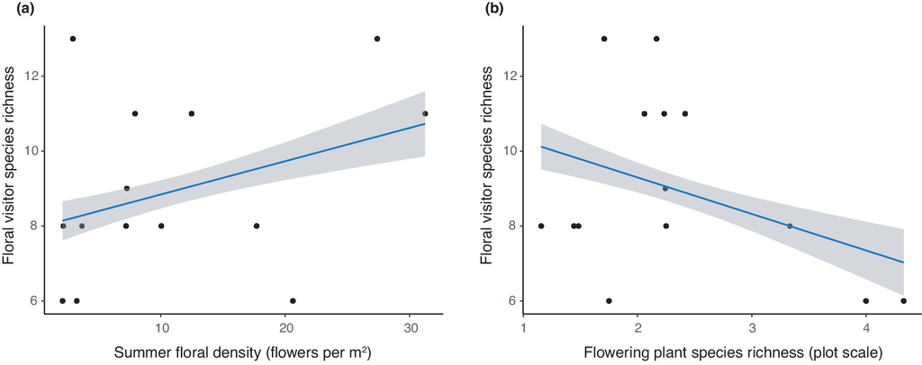

**FIGURE 1**

Relationship between pollinator species richness and summer floral density (a) and year-round plot scale flowering plant species richness (b)

### 3.2 Floral visitation rate

Overall floral visitation rate was positively associated with quadrat scale summer floral density (*p* = 0.003). The full model (containing covariates) explained a moderate amount of variation in visitation (*R*<sup>2</sup> = 0.32), however, the subset model (containing only floral density) explained a much smaller proportion of visitation rate (*R*<sup>2</sup> = 0.02). No other models were within ΔAICc < 2 of this model (S6.2).

*Apis mellifera* visitation rate was best explained by a model that included a positive relationship with summer floral density and a negative relationship with quadrat scale species richness across the year (*p* = 0.04, *R*<sup>2</sup> full model = 0.81, *R*<sup>2</sup> subset model = 0.42). Two other models were within ΔAICc < 2, each containing one of these two variables (S6.3).

Visitation rate of social bees combined (*A. mellifera* and *T. carbonaria*), was negatively related to plot scale summer flowering species richness and positively related to mean floral density and the presence of *T. carbonaria* hives (*p* < 0.001, *R*<sup>2</sup> full model = 0.67, *R*<sup>2</sup> subset model = 0.59). No other models were within ΔAICc < 2 of this model (S6.4).

Hoverfly visitation rate was best explained by a model that contained a negative relationship with plot size and a positive relationship with garden scale summer floral species richness (*p* < 0.001, *R*<sup>2</sup> full model = 0.54, *R*<sup>2</sup> subset model = 0.43). The only other model within ΔAICc < 2 of this model was one that included only a negative relationship with plot size (S6.5).

### 3.3 Experimental plant reproductive output

The reproductive output of hand pollinated plants did not differ from naturally pollinated plants. This was the case when examining the raw data (Wilcoxon test for difference between treatment means: weight of individual seeds *p* = 0.976, number of seeds per pod *p* = 0.936, pod production ratio *p* = 0.131) and the log response ratios (*t*-test for difference from 0: weight of individual seeds *p* = 0.94, number of seeds per pod *p* = 0.44, pod production *p* = 0.89). It was thus concluded that experimental plants were likely not pollen limited and hand pollinated plants were excluded from further analysis.

Number of seeds per pod was positively related to number of visiting species per flower and negatively related to mean number of visits per flower and garden vegetation complexity, with the most highly ranked model containing these three variables (*p* = 0.003, *R*<sup>2</sup> = 0.14, Figure 2). No other models were within ΔAICc < 2 of this model (S6.6).

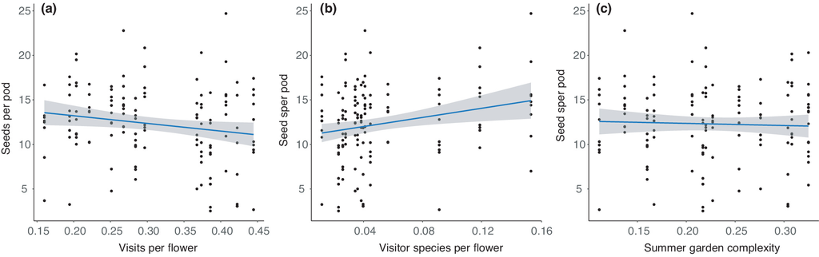

**FIGURE 2**

Relationship between seeds per pod and number of visitors per flower (a), species visiting per flower (b) and summer garden vegetation complexity (c)

We found no relationship between pod production or seed weight and any explanatory variables, with the highest ranked model in both cases being the null model (S6.7 and S6.8).

### 3.4 Food crop yields

Sixty-two varieties of crops were harvested by the 13 gardeners who provided data. Of these, only 19 were varieties that potentially see improved productivity as a result of insect pollination, with the remaining 43 being leaf or root crops or plants that rely on abiotic pollination.

Crop yield (kg/m<sup>2</sup>) was positively related to canopy cover within 100 m and garden scale plant species richness, with the highest ranked model containing only these two variables (*p* = 0.002, marginal *R*<sup>2</sup> = 0.66). Two other models were within ΔAICc < 2 of this model, both containing the same two variables but adding garden size (positive relationship) and buildings within 500 m (positive relationship) (S6.9).

Yield per hour was best explained by a model that included a positive relationship with garden scale plant species richness, along with a negative relationship with distance to nearest bushland (*p* = 0.043, *R*<sup>2</sup> = 0.40). No other models within ΔAICc < 2 of this model were statistically significant (S6.10).

## 4 DISCUSSION

Urban agricultural systems can host diverse pollinators which can provide substantial pollination services to model plants while influenced by a range of features in the surrounding environment. Pollinator richness was most strongly influenced by floral variables, including a positive relationship with floral density and a negative relationship with floral richness. Visitation rate showed a similar trend, with overall visitation, honeybee visitation and combined social bee visitation all showing a positive relationship with number of flowers, while honeybees and social bees combined responded negatively to some aspects of plant species richness. Hoverfly visitation showed the opposite trend, responding positively to flowering species richness during summer. These findings provide evidence that pollinators in urban environments can be influenced by some of the same factors that are relevant in rural settings (Klein et al., 2007).

The negative relationship observed between pollinator richness and floral species richness may be a result of competition between model plants and plants present within the gardens (Mesgaran et al., 2017). As we only observed pollinators visiting model plants, rather than surveying gardens more generally, a greater proportion of the flower visiting species present in more florally diverse gardens may have been missed due to a preference for flowers other than those on model plants.

We observed that model plants were not pollen limited, likely a result of the high level of visitation. If the average rate of visitation recorded during observation periods continued across the typical 3 day life span of a *B. rapa* flower this would result in 18 visits per flower (conservatively assuming the observed rate occurred for just 6 hr per day), a visitation rate more than three orders of magnitude greater than that experienced by brassicaceous seed crops in some rural systems (Ouvrard et al., 2017) and around twice the rate at which it has been estimated maximum pollination occurs in other brassica species (Stanley et al., 2017). While floral attractiveness and pollination requirements can vary greatly between crop plants (Klein et al., 2007), these findings show that the pollinators in our study sites have the potential to provide sufficient pollination services to at least a subset of plants.

While floral resources were positively related to visitation rate or visitor richness, care should be taken in assuming such results are indicative of increased pollination services. Given our findings regarding lack of pollen limitation, two of the three plant reproductive metrics examined showed no significant response to any of the potential explanatory variables tested, however, seeds per pod did show a weak response (*R*<sup>2</sup> = 0.14) to some factors. This variable was positively influenced by species richness of floral visitors, but was negatively impacted by number of visits per flower, possibly indicating high visitation rates damage floral stigmas (Saez et al., 2014).

These findings illustrate the importance of measuring both pollinator visitation and plant reproduction metrics, rather than simply assuming that pollination follows visitation trends. Numerous studies have reported similar findings of pollinator communities being positively related to floral resources present within urban gardens (e.g. Davis et al., 2017; Lin et al., 2015; Matteson & Langellotto, 2010; Quistberg et al., 2016), however, only a minority of these examined the actual pollination services realised within these systems. The negative relationship reported here between experimental plant reproduction and floral visitation indicates that the interaction between insect activity and pollination is complex and not always positive.

While our experimental design was limited in its capacity to detect relationships between pollinator community variables and food crop yield (due to pollinator dependent species making up only a small, variable, proportion of crops in each garden), yield was nonetheless strongly influenced by environmental factors. Our most highly ranked model found two thirds of variability in yield per m<sup>2</sup> was explained by local canopy cover and garden scale species richness. One possible explanation for this is the ‘urban heat island’ a phenomenon whereby cities are often warmer than surrounding rural or natural environments due to higher levels of heat-retaining surfaces, increased atmospheric CO<sub>2</sub> and reduced evapotranspiration (Wortman & Lovell, 2013). Increased temperatures resulting from this can cause heat stress in plants (Baker et al., 2002), potentially reducing yields. Increased canopy cover can help mitigate the urban heat island effect by shading heat-retaining surfaces and increasing evapotranspiration (Akbari, 2002), which could potentially explain the positive relationship between canopy cover and yield.

Garden scale plant species richness was also found to positively impact crop yield, possibly as a result of more diverse gardens ‘over-yielding’ (Ackerman et al., 2013), a potential increase in pest control services (Albrecht et al., 2020) or due to both higher yield and diversity being indicative of more intensive management (Cook et al., 2012). Yield per hour of labour showed a similar relationship with plant species richness as yield per m<sup>2</sup> and also decreased with increasing distance to bushland, possibly also due to the urban island effect.

The stronger impacts of environmental variables on crop yield, compared to pollination, may be a result of the diversity of crops within the gardens compared to the single model plant we examined. Aspects of the environment made small differences to one aspect of *B. rapa* reproduction and the large effects on yield may result from differences like these adding up when summed across the range of species and ecosystem services found within the study sites.

## 5 CONCLUSIONS

This research has shown that urban food gardens can have diverse and highly active pollinator assemblages that provide substantial pollination services to at least a subset of crops. Importantly, the environmental factors known to benefit pollinators in rural farmland can also increase pollinator richness and visitation in urban gardens. However, evaluating pollination services in urban gardens requires a deeper understanding of the complex relationship between floral resources, flower visitation and plant reproduction as increasing pollinator visitation in urban gardens may not necessarily benefit the reproduction of all plants.

While environmental features had a minor impact on pollination of model plants, they had a much larger impact on food plant output when yield was summed across all crops grown in the study sites, including those not dependent on insect pollinators. This implies that assessments of ecosystem services in urban environments, and management decisions related to these, may be better focused on outcomes from systems of diverse species communities, rather than on the provision of single services or the success of a single plant species. As yields of garden crops, whether pollinator dependent or not, were more strongly influenced by surrounding environmental variables than pollination-related metrics, policies to support pollinator richness will likely differ to those supporting crop yields in urban gardens and will require assessment and management of external environmental factors.

## ACKNOWLEDGEMENTS

We thank Mark Hall and Manu Saunders for assistance with insect identification and Finlay McDougall for field assistance. R.M. was funded by an Australian Postgraduate Award at the University of New England, Armidale Australia. R.R. was funded by the Australian Research Council (FT210100851).

## CONFLICT OF INTEREST

R.R. is a Senior Editor of Journal of Applied Ecology but took no part in the peer review and decision-making process for this paper. Other authors have no potential conflict of interest.

## AUTHORS' CONTRIBUTIONS

R.M., R.R., P.K. and T.L. conceived the ideas and designed methodology; R.M. collected data and led data analysis and writing of the manuscript. All authors contributed to data analysis, contributed critically to drafts and gave final approval for publication.

## REFERENCES

[figure not shown]